# DGE/DTU - IsoSeq Raw Data

Szi Kay Leung

Report created: 2020-11-03

# Aim

This analysis has been adapted from **`Nanopore_Transcriptome_Tutorial.Rmd`*:  
- Identify the gene isoforms that are expressed and the number of sequence reads that are observed from each gene isoform (and parental gene).  
- Map sequence reads to the reference transcriptome using Minimap2 and quantify the number of reads associated with each isoform/gene using Salmon - Perform a statistical analysis using edgeR (McCarthy et al. (2012)) to identify differentially expressed genes and DEXSeq (Reyes et al. (2013)) and stageR (Van den Berge and Clement (2018)) to identify differentially used transcripts.

# Study design

The study design described by the configuration file is presented in the table below.

|  | filename | group | replicate |
| --- | --- | --- | --- |
| A1 | Q21.clustered.hq.fastq | WT | 1 |
| A2 | K17.clustered.hq.fastq | WT | 2 |
| A3 | M21.clustered.hq.fastq | WT | 3 |
| A4 | O23.clustered.hq.fastq | WT | 4 |
| A5 | S23.clustered.hq.fastq | WT | 5 |
| A6 | K23.clustered.hq.fastq | WT | 6 |
| B1 | O18.clustered.hq.fastq | TG | 1 |
| B2 | K18.clustered.hq.fastq | TG | 2 |
| B3 | S18.clustered.hq.fastq | TG | 3 |
| B4 | L22.clustered.hq.fastq | TG | 4 |
| B5 | Q20.clustered.hq.fastq | TG | 5 |
| B6 | K24.clustered.hq.fastq | TG | 6 |

*Table showing the cDNA sequence files evaluated for DGE and DTU. Treatment group and replicate number are shown for each of the sequence files.*

# Review of length and mapping

### Raw cDNA sequences

The summary statistics displayed include observational metrics such as the number of sequence reads, information on the longest, shortest and mean read lengths, GC content, N50 and N90 read lengths. Ideally sequences from each library will have similar characteristics. Large differences in e.g. the number of reads, overall read quality and GC content may indicate technical differences between the samples - such differences may confound the statistical analysis and hinder the identification of differentially expressed genes and transcripts.

|  | A1 | A2 | A3 | A4 | A5 | A6 | B1 | B2 | B3 | B4 | B5 | B6 |
| --- | --- | --- | --- | --- | --- | --- | --- | --- | --- | --- | --- | --- |
| reads | 30,871 | 32,738 | 29,808 | 33,505 | 33,548 | 33,893 | 31,385 | 32,305 | 31,212 | 32,201 | 33,119 | 32,596 |
| mbs | 99 | 65.1 | 79.7 | 73.5 | 66.2 | 83.5 | 99.4 | 56.6 | 65.1 | 83.9 | 88.6 | 79.3 |
| min | 71 | 51 | 76 | 54 | 51 | 51 | 76 | 51 | 51 | 51 | 51 | 51 |
| max | 14302 | 15014 | 14358 | 14344 | 14410 | 14307 | 10920 | 10235 | 10691 | 15920 | 14856 | 14826 |
| mean | 3206.4 | 1987.2 | 2673.5 | 2193.8 | 1973.3 | 2463.8 | 3168.4 | 1751.9 | 2087.2 | 2604.3 | 2674.4 | 2432.3 |
| median | 3082 | 1616 | 2493 | 1870 | 1680 | 2302 | 3026 | 1539 | 1796 | 2490 | 2498 | 2116 |
| qval | 29 | 29 | 29 | 29 | 29 | 29 | 29 | 29 | 29 | 29 | 29 | 29 |
| gc | 50.5 | 50.2 | 50.1 | 50.3 | 49.3 | 49.6 | 50.2 | 49.4 | 51.3 | 50.4 | 49.8 | 49.7 |
| n50 | 3533 | 2945 | 3072 | 3067 | 2831 | 3258 | 3451 | 2370 | 2717 | 3347 | 3420 | 3260 |
| l50 | 10862 | 7556 | 9467 | 8462 | 8335 | 9480 | 11181 | 8330 | 8188 | 9400 | 9631 | 8735 |
| n90 | 2242 | 1106 | 1688 | 1263 | 1120 | 1478 | 2199 | 1013 | 1208 | 1595 | 1602 | 1403 |
| l90 | 24600 | 21309 | 22887 | 22745 | 22384 | 23727 | 25282 | 22103 | 22007 | 22974 | 23931 | 22966 |

*Table presenting summary statistics for the cDNA libraries imported*

### Review of cDNA read mapping

These mapping statistics are useful for evaluating the concordance of different sequence libraries and thus the overall quality of the study - ideally there should be robust similarities in the fraction of mapping sequence reads / multi-mapping reads etc.

|  | A1 | A2 | A3 | A4 | A5 | A6 | B1 | B2 | B3 | B4 | B5 | B6 |
| --- | --- | --- | --- | --- | --- | --- | --- | --- | --- | --- | --- | --- |
| nreads | 30871 | 32738 | 29808 | 33505 | 33548 | 33893 | 31385 | 32305 | 31212 | 32201 | 33119 | 32596 |
| read mappings | 51798 | 56564 | 44029 | 56739 | 56064 | 54407 | 50924 | 56631 | 52288 | 53222 | 52245 | 52001 |
| Secondary | 19160 | 22296 | 12405 | 21089 | 20877 | 18542 | 17941 | 22985 | 19504 | 18422 | 16736 | 17285 |
| Supplementary | 1767 | 1530 | 1816 | 2145 | 1639 | 1972 | 1598 | 1341 | 1572 | 2599 | 2390 | 2120 |
| Duplicates | 0 | 0 | 0 | 0 | 0 | 0 | 0 | 0 | 0 | 0 | 0 | 0 |
| %mapping | 100 | 100 | 100 | 100 | 100 | 100 | 100 | 100 | 100 | 100 | 100 | 100 |

*Table showing summary statistics from the minimap2 long read mapping of reads to the reference transcriptome*

# Salmon: Assigning mapped cDNA sequence reads to transcripts

## Isoforms to Genes

The next step in the sequence analysis is to map gene isoforms back to their parental genes for gene level analysis. This utilises the genome annotation **`gff`** file described in the **`config.yaml`** file.

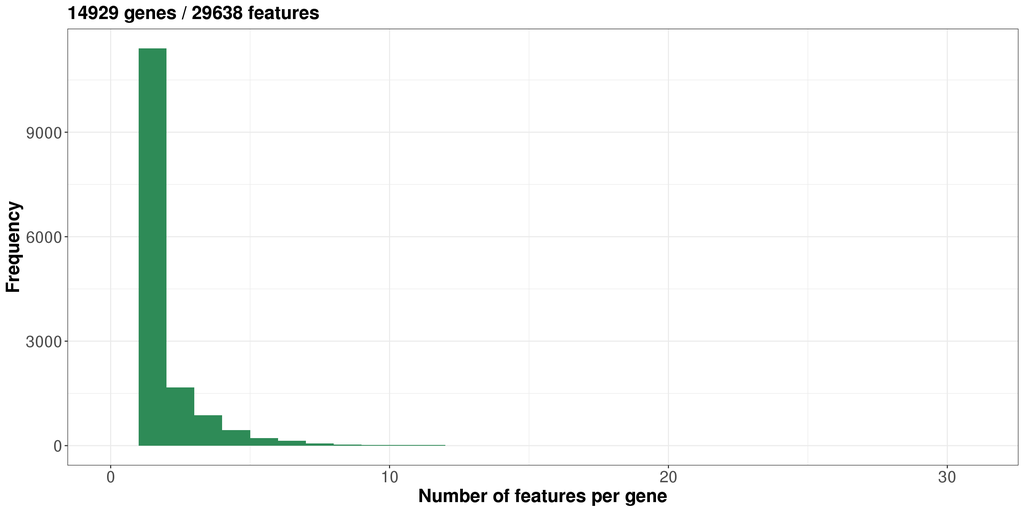

*Frequency plot showing the number of transcripts assigned to genes across the sampled cDNA sequence collection*

# DRIMSeq: Read filtering

**`DRIMSeq`** (@R-DRIMSeq) is used to filter the transcript count data from the **`salmon`** analysis. The filter step will be used to select for genes and transcripts that satisfy rules for the number of samples in which a gene or transcript must be observed and minimum threshold levels for the number of observed reads. The parameters defined for this analysis include

- `min_samps_gene_expr` = **3** - a transcript must be mapped to a *gene* in at least this *minimum number of samples* for the *gene* be included in the analysis
- `min_samps_feature_expr` = **1** - a transcript must be mapped to an *isoform* in at least this this *minimum number of samples* for the *gene isoform* to be included in the analysis
- `min_gene_expr` = **10** - the *minimum number of total mapped sequence reads* for a gene to be considered *expressed*
- `min_feature_expr` = **3** - the *minimum number of total mapped sequence reads* for a *gene isoform* to be considered

# EdgeR: Differential gene expression analysis

A statistical analysis is first performed using **`edgeR`** (@R-edgeR2010, @R-edgeR2012) to identify the subset of differentially expressed genes. The filtered list of gene counts is used as input. A normalisation factor is calculated for each sequence library (using the default `TMM` method - please see @R-edgeR2012 for further details). The defined experimental design is used to calculate estimates of dispersion across for each of the gene features. Genewise statistical tests are then calculated, again using the contrasts defined in the experimental design. The differentially expressed genes are corrected for false discovery (*fdr*) using the method of Benjamini & Hochberg (@BH1995)

The results from the **`edgeR`** analysis can be plotted as an **`MA Plot`**. This plot visualises differences in measurements between the two experimental conditions. M is the log2 ratio of gene expression calculated between the conditions. A is a log2 transformed mean expression value. The figure below presents the MA figure from this edgeR analysis. Genes that satisfy the *logFC* and FDR corrected *p-value* thresholds defined in the **`config.yaml`** configuration file are shaded.

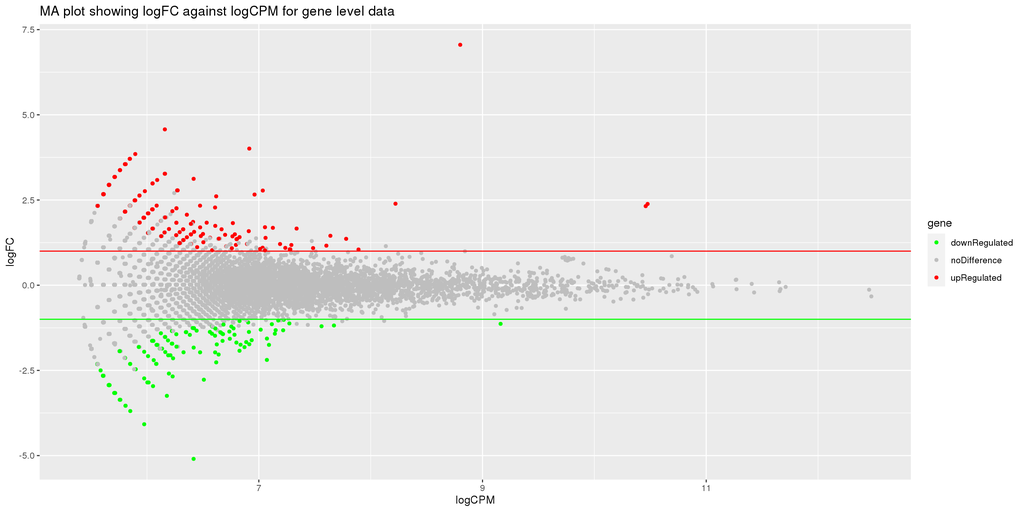

# DeSeq2: Differential gene expression analysis

```r
#coldata <- data.frame("group" = studyDesign$group)
#rownames(coldata) <- colnames(gene_cts)
#dds <- DESeqDataSetFromMatrix(countData = as.matrix(gene_cts),
                              #colData = coldata,
                              #design= ~ group)
```

# Differential transcript usage analysis

Differential transcript usage analysis is performed using the *R* **`DEXSeq`** package (@R-DEXSeq). Similar to the **`edgeR`** package, **`DEXSeq`** estimates the variance between the biological replicates and applies generalised linear models for the statistical testing. The key difference is that the **`DEXSeq`** method is looking for differences at the exon count level.

**`DEXSeq`** uses the filtered transcript count data prepared earlier in this analysis.

|  | Log2MeanExon | Log2FC | pvalue | padj |
| --- | --- | --- | --- | --- |
| ENSMUSG00000079037.9:ENSMUST00000091288.12 | 5.74 | 0.26 | 5.288949e-05 | 0.0851125 |
| ENSMUSG00000079037.9:ENSMUST00000142070.1 | 3.31 | -1.88 | 2.904843e-05 | 0.0851125 |
| ENSMUSG00000024617.16:ENSMUST00000134496.1 | -0.01 | -12.69 | 5.918811e-05 | 0.0851125 |
| ENSMUSG00000033793.12:ENSMUST00000044369.12 | 2.64 | 0.12 | 4.188421e-01 | 1.0000000 |
| ENSMUSG00000033793.12:ENSMUST00000192698.2 | 0.73 | -0.47 | 4.268596e-01 | 1.0000000 |
| ENSMUSG00000025920.19:ENSMUST00000162751.7 | 1.88 | -0.02 | 9.479122e-01 | 1.0000000 |
| ENSMUSG00000025920.19:ENSMUST00000027052.12 | 1.23 | -0.12 | 8.131038e-01 | 1.0000000 |
| ENSMUSG00000025920.19:ENSMUST00000159558.7 | 0.91 | 0.27 | 6.393457e-01 | 1.0000000 |
| ENSMUSG00000025920.19:ENSMUST00000128957.8 | 2.23 | -0.12 | 7.121709e-01 | 1.0000000 |
| ENSMUSG00000025920.19:ENSMUST00000162007.7 | 1.09 | -0.11 | 8.269350e-01 | 1.0000000 |
| ENSMUSG00000025920.19:ENSMUST00000127420.7 | 0.31 | 0.52 | 4.820816e-01 | 1.0000000 |
| ENSMUSG00000041670.16:ENSMUST00000081544.12 | 0.65 | -0.23 | 7.269743e-01 | 1.0000000 |
| ENSMUSG00000041670.16:ENSMUST00000097809.9 | 0.72 | 0.21 | 6.606200e-01 | 1.0000000 |
| ENSMUSG00000041670.16:ENSMUST00000115273.8 | 0.65 | 0.35 | 5.177493e-01 | 1.0000000 |
| ENSMUSG00000041670.16:ENSMUST00000097810.9 | 0.40 | -0.16 | 8.669627e-01 | 1.0000000 |

*Table showing the top 15 gene isoforms, ranked by adjusted p-value, from the DEXSeq analysis. Information shown includes the log2 fold change between experimental conditions, the log-scaled transcript abundance and the false discovery corrected p-value (FDR). This table has not been filtered for genes that satisfy statistical or magnitudinal thresholds*

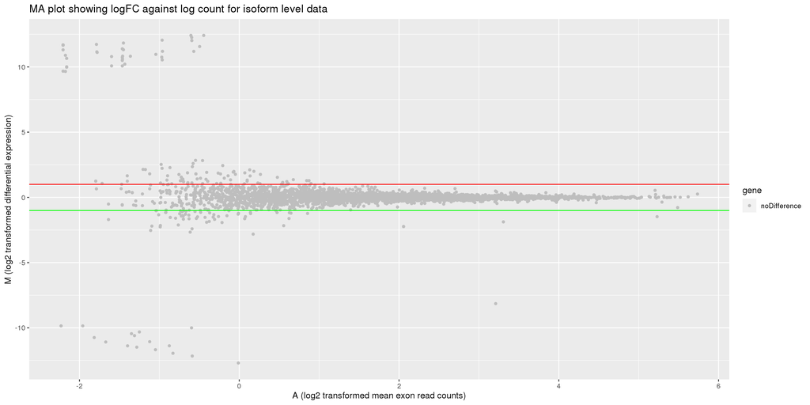

```
/gpfs/mrc0/projects/Research_Project-MRC148213/sl693/WholeTranscriptome/Tg4510/Diff_Analysis/DTU/Isoseq_Raw/Results/AlternativelySplicedGenes.xlsx
```

The Excel format spreadsheet file indicated above contains the output of the **`DEXSeq`** DTU analysis.

# stageR analysis

The final component of this cDNA sequence based gene isoform analysis is a stage-wise statistical analysis using the **`R`** software package called **`stageR`** (@R-stageR). **`stageR`** uses (1) the raw p-values for DTU from the **`DEXSeq`** analysis in the previous section and (2) a false-discovery corrected set of p-values from testing whether individual genes contain at least one exoning showing DTU. A hierarchical two-stage statistical testing evaluates the set of genes for DTU.

```
/gpfs/mrc0/projects/Research_Project-MRC148213/sl693/WholeTranscriptome/Tg4510/Diff_Analysis/DTU/Isoseq_Raw/Results/StageRDiffTranscriptUsage.xlsx
```

The matrix of gene and transcript identifiers and the probability that they are showing any form of DTU has been written to an Excel format spreadsheet file at the path shown above.

| gene_id | transcript_id | p_gene | p_transcript |
| --- | --- | --- | --- |

*Table showing gene and transcript identifiers and their FDR corrected probabilities for the genes and their isoforms that have been identified as showing DTU using the R packages DEXSeq and StageR. This list has been shortened requiring that both gene and transcript must satisfy the p-value threshold*

| gene_id | transcript_id | A1 | A2 | A3 | A4 | A5 | A6 | B1 | B2 | B3 | B4 | B5 | B6 | p_gene | p_transcript |
| --- | --- | --- | --- | --- | --- | --- | --- | --- | --- | --- | --- | --- | --- | --- | --- |

[figure not shown]

| gene_id | transcript_id | A1 | A2 | A3 | A4 | A5 | A6 | B1 | B2 | B3 | B4 | B5 | B6 | p_gene | p_transcript |
| --- | --- | --- | --- | --- | --- | --- | --- | --- | --- | --- | --- | --- | --- | --- | --- |

[figure not shown]

# Output

The complete transcript mapping data is provided as a CSV format file at ~~<sub>/gpfs/mrc0/projects/Research_Project-MRC148213/sl693/WholeTranscriptome/Tg4510/Diff_Analysis/DTU/Isoseq_Raw/Results/ExpressedTranscripts.csv</sub>~~

An CSV format file containing the transcript mapping counts and parental gene assignments has been prepared and is available in the following folder.

```
/gpfs/mrc0/projects/Research_Project-MRC148213/sl693/WholeTranscriptome/Tg4510/Diff_Analysis/DTU/Isoseq_Raw/Results/ExpressedGenesTranscripts.csv
```

The filtered gene counts and gene isoform counts have been written to Excel format spreadsheet files in the paths indicated below.

```
/gpfs/mrc0/projects/Research_Project-MRC148213/sl693/WholeTranscriptome/Tg4510/Diff_Analysis/DTU/Isoseq_Raw/Results/FilteredExpressedGeneCounts.xlsx
/gpfs/mrc0/projects/Research_Project-MRC148213/sl693/WholeTranscriptome/Tg4510/Diff_Analysis/DTU/Isoseq_Raw/Results/FilteredExpressedFeatureCounts.xlsx
```

The filtered gene counts and gene isoform counts have been written to Excel format spreadsheet files in the paths indicated above. ~~<sub>/gpfs/mrc0/projects/Research_Project-MRC148213/sl693/WholeTranscriptome/Tg4510/Diff_Analysis/DTU/Isoseq_Raw/Results/FilteredExpressedGeneCounts.xlsx /gpfs/mrc0/projects/Research_Project-MRC148213/sl693/WholeTranscriptome/Tg4510/Diff_Analysis/DTU/Isoseq_Raw/Results/FilteredExpressedFeatureCounts.xlsx</sub>~~

# Reproducible research - produce your own report